# Biostatistical Computing, PHC 6068

Vectorized calculation

Zhiguang Huo (Caleb)

Monday September 6, 2017

# Why do we need vectorized calculation (motivating example 1)

- Elegant and efficient
- R is slow in loops but fast for vectorized calculation.

```r
a <- 1:1000000
### version A, loop
start <- Sys.time()
meanA <- 0
for(i in seq_along(a)){
  meanA <- meanA + a[i]/length(a)
}
end <- Sys.time()
end - start
```

```
## Time difference of 1.313023 secs
```

```r
meanA
```

```
## [1] 500000.5
```

```r
### version B, vectorized calculation
start <- Sys.time()
mean(a)
```

```
## [1] 500000.5
```

```r
end <- Sys.time()
end - start
```

```
## Time difference of 0.005419016 secs
```

# Why do we need vectorized calculation (motivating example 2)

- Elegant and efficient
- R is slow in loops but fast for vectorized calculation.

```r
a <- 1:1000000
b <- 1000000:1
### version A, loop
start <- Sys.time()
result <- numeric(length(a)) ## create a vector with length length(a) and all elements 0
for(i in seq_along(a)){
  result[i] <- a[i] + b[i]
}
end <- Sys.time()
end - start
```

```
## Time difference of 2.219551 secs
```

```r
### version B, vectorized calculation
start <- Sys.time()
result <- a + b
end <- Sys.time()
end - start
```

```
## Time difference of 0.01295304 secs
```

# Simple examples of vectorized calculation

- vector algebra

```r
a <- c(1.1,3.4,9.5)
b <- c(9,2,0.8)
a + b ## vector addition
```

```
## [1] 10.1  5.4 10.3
```

```r
a * b ## vector multiplication
```

```
## [1] 9.9 6.8 7.6
```

```r
a ^ b ## 1.1^9, 3.4^2, 9.5^0.8
```

```
## [1]  2.357948 11.560000  6.055903
```

# Simple examples of vectorized calculation 2

- vector with scalor

```r
a <- 1:8
a + 2
```

```
## [1]  3  4  5  6  7  8  9 10
```

```r
a + c(0,1)
```

```
## [1] 1 3 3 5 5 7 7 9
```

```r
a + c(1,2,3) ## warming message
```

```
## [1]  2  4  6  5  7  9  8 10
```

# Other scientific calculation

```r
a <- seq(1,3,1)
sin(a)
```

```
## [1] 0.8414710 0.9092974 0.1411200
```

```r
tan(a)
```

```
## [1]  1.5574077 -2.1850399 -0.1425465
```

```r
log(a,base = 10)
```

```
## [1] 0.0000000 0.3010300 0.4771213
```

```r
log10(a)
```

```
## [1] 0.0000000 0.3010300 0.4771213
```

```r
exp(a)
```

```
## [1]  2.718282  7.389056 20.085537
```

# vectorized input for plot

- all vector input

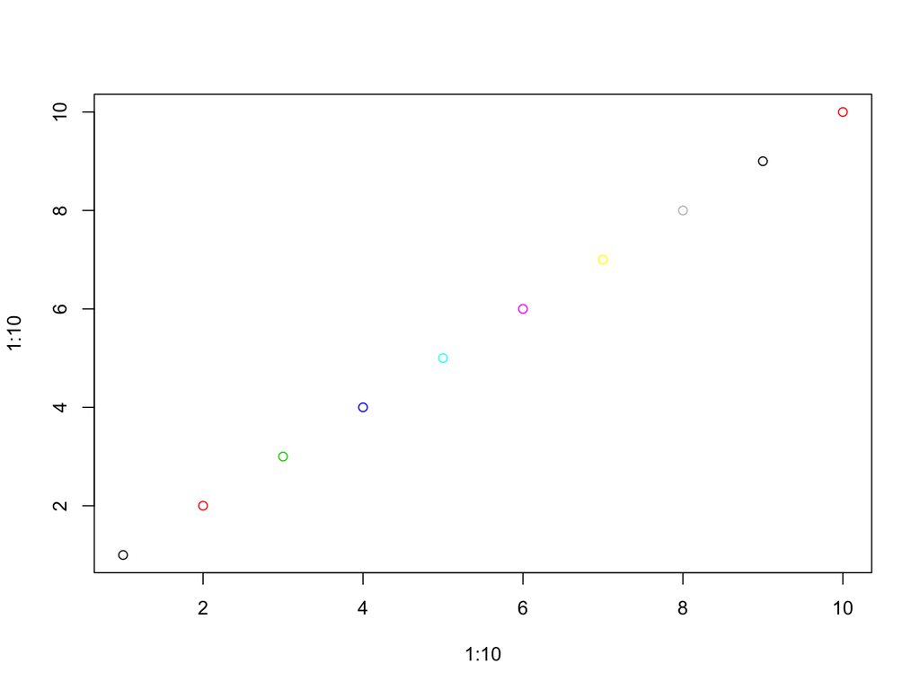

```r
plot(x = 1:10, y = 1:10, col=1:10)
```

- vector input + scalor input

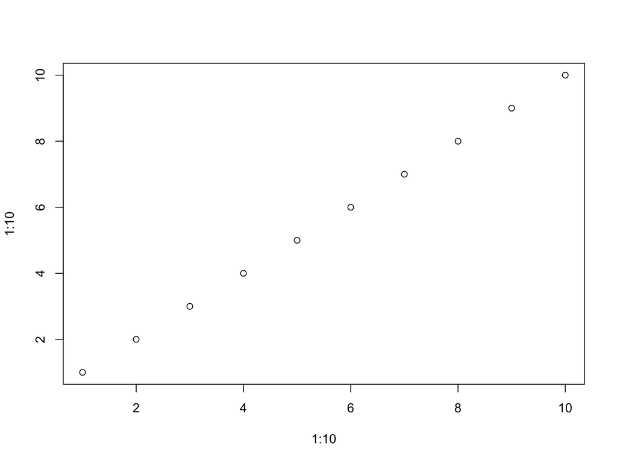

```r
plot(x = 1:10, y = 1:10, col=1)
```

# Initialize a vector

```r
n <- 5
a_int <- integer(n)
a_int
```

```
## [1] 0 0 0 0 0
```

```r
b_int <- rep(0, n)
b_int
```

```
## [1] 0 0 0 0 0
```

```r
c_int <- replicate(5,0)
c_int
```

```
## [1] 0 0 0 0 0
```

# Initialize a vector, other types

```r
a_double <- double(n)
a_double
```

```
## [1] 0 0 0 0 0
```

```r
a_char <- character(n)
a_char
```

```
## [1] "" "" "" "" ""
```

```r
a_logical <- logical(n)
a_logical
```

```
## [1] FALSE FALSE FALSE FALSE FALSE
```

# A sequence

```r
a <- seq(from=10, to=100, by=2)
a
```

```
##  [1]  10  12  14  16  18  20  22  24  26  28  30  32  34  36  38  40  42
## [18]  44  46  48  50  52  54  56  58  60  62  64  66  68  70  72  74  76
## [35]  78  80  82  84  86  88  90  92  94  96  98 100
```

```r
b <- seq(from=10, to=100, length=10)
b
```

```
##  [1]  10  20  30  40  50  60  70  80  90 100
```

```r
c <- seq(from=10, to=100, along.with=1:10)
c
```

```
##  [1]  10  20  30  40  50  60  70  80  90 100
```

# Random number generator

- Random numbers from normal distribution

```r
set.seed(32611) ## set a seed number such that the random numbers will keep the same
rnorm(n = 5, mean = 0, sd = 1)
```

```
## [1] -0.1023726 -1.8869039 -1.0586563  1.0227599  0.3982516
```

- mean and sd parameter can also be vectorized.

```r
set.seed(32611)
rnorm(n = 5, mean = 0:4, sd = 1)
```

```
## [1] -0.1023726 -0.8869039  0.9413437  4.0227599  4.3982516
```

- Random numbers from 1:10

```r
set.seed(32611)
sample(1:10,1)
```

```
## [1] 5
```

- Random numbers from Uniform distribution U(0,1)

```r
set.seed(32611)
runif(n = 4)
```

```
## [1] 0.45923048 0.37486058 0.02958663 0.51775341
```

# replicate

- replicate empty list

```r
replicate(4,list())
```

```
## [[1]]
## list()
##
## [[2]]
## list()
##
## [[3]]
## list()
##
## [[4]]
## list()
```

- a complicate example by replicate

```r
replicate(5, runif(sample(1:5,1)))
```

```
## [[1]]
## [1] 0.02609954
##
## [[2]]
## [1] 0.4031372 0.6547776 0.5071504 0.2504906 0.9807351
##
## [[3]]
## [1] 0.8903292 0.5409666 0.5041831
##
## [[4]]
## [1] 0.7552580 0.5850660 0.9150680 0.2715686
##
## [[5]]
## [1] 0.8858161 0.1869268
```

# Matrix calculation

```r
a <- matrix(1:6,nrow=3,ncol=2)
a ## matrix will be filled by column by default.
```

```
##      [,1] [,2]
## [1,]    1    4
## [2,]    2    5
## [3,]    3    6
```

```r
b <- matrix(6:1, nrow=3, ncol=2)
a * b ## similar to vector, matrix algebra will be done element-wise.
```

```
##      [,1] [,2]
## [1,]    6   12
## [2,]   10   10
## [3,]   12    6
```

```r
a + c(1,2,3) ## if a matrix add a vector, add by column
```

```
##      [,1] [,2]
## [1,]    2    5
## [2,]    4    7
## [3,]    6    9
```

# apply function: works on margins of a matrix (1)

```r
a <- matrix(1:6,nrow=3,ncol=2)
a
```

```
##      [,1] [,2]
## [1,]    1    4
## [2,]    2    5
## [3,]    3    6
```

```r
apply(a,1,sum) ## for each row, equivalent to rowSums
```

```
## [1] 5 7 9
```

```r
apply(a,1,var) ## for each row, calculate the variance
```

```
## [1] 4.5 4.5 4.5
```

```r
apply(a,1,function(x) x^2) ## can also use an anonymous function, note that R will always fill the result by column.
```

```
##      [,1] [,2] [,3]
## [1,]    1    4    9
## [2,]   16   25   36
```

# apply function: works on margins of a matrix (2)

```r
apply(a,2,sum) ## for each column, equivalent to colSums
```

```
## [1]  6 15
```

```r
colSums(a)
```

```
## [1]  6 15
```

```r
apply(a,2,mean) ## for each column, equivalent to colMeans
```

```
## [1] 2 5
```

```r
apply(a,2,function(x) min(x)) ## equivalent to apply(a,2,min)
```

```
## [1] 1 4
```

```r
apply(a,2,min)
```

```
## [1] 1 4
```

# Sweep

- sweep() allows you to “sweep” out the values of a summary statistic. It is often used with apply() to standardise arrays.

```r
set.seed(32611)
(x <- matrix(rnorm(6,0,4),nrow=2))
```

```
##            [,1]      [,2]      [,3]
## [1,] -0.4094903 -4.234625  1.593006
## [2,] -7.5476157  4.091040 -2.691786
```

```r
x1 <- sweep(x,1,apply(x,1,min),'-')
x1
```

```
##          [,1]     [,2]     [,3]
## [1,] 3.825135  0.00000 5.827631
## [2,] 0.000000 11.63866 4.855829
```

```r
x2 <- sweep(x1,1,apply(x1,1,max),'/')
x2
```

```
##          [,1] [,2]      [,3]
## [1,] 0.656379    0 1.0000000
## [2,] 0.000000    1 0.4172157
```

# lapply()

- lapply will apply a function to each element of a list
- lapply() is written in C for performance,

```r
l <- list(c(1:10), list(a='a'), c("dog","cat","gator"))
unlist(lapply(l, length))
```

```
## [1] 10  1  3
```

- a simple R implementation that does the same thing:

```r
lapply2 <- function(x, f, ...){
  out <- vector("list", length(x))
  for(i in seq_along(x)){
    out[[i]] <- f(x[[i]], ...)
  }
  out
}
unlist(lapply2(l, length))
```

```
## [1] 10  1  3
```

# lapply usages

```r
alist <- list(a = 25, b = 100, c = 64)
```

- loop over the elements: for (x in xs)

```r
lapply(alist, function(x) sqrt(x))
```

```
## $a
## [1] 5
##
## $b
## [1] 10
##
## $c
## [1] 8
```

- loop over the numeric indices: for (i in seq_along(xs))

```r
lapply(seq_along(alist), function(x) sqrt(alist[[x]]))
```

```
## [[1]]
## [1] 5
##
## [[2]]
## [1] 10
##
## [[3]]
## [1] 8
```

- loop over the names: for (nm in names(xs))

```r
lapply(names(alist), function(x) sqrt(alist[[x]]))
```

```
## [[1]]
## [1] 5
##
## [[2]]
## [1] 10
##
## [[3]]
## [1] 8
```

# lapply on data.frame

- data.frame shares the property of a list and a matrix

```r
aframe <- data.frame(col1=1:3,col2=4:6)
lapply(aframe, mean) ## as a list
```

```
## $col1
## [1] 2
##
## $col2
## [1] 5
```

```r
apply(aframe, 2, mean) ## as a matrix
```

```
## col1 col2
##    2    5
```

# lapply on a list of functions

```r
compute_mean <- list(
  base = function(x) mean(x),
  sum = function(x){
    sum(x)/length(x)},
  mannual = function(x){
    total <- 0
    n <- length(x)
    for(i in seq_along(x)){
      total <- total + x[i]/n
    }
    total
  }
)

set.seed(32611)
x <- runif(1e5)
lapply(compute_mean,function(f) system.time(f(x)))
```

```
## $base
##    user  system elapsed
##   0.001   0.000   0.001
##
## $sum
##    user  system elapsed
##   0.000   0.000   0.001
##
## $mannual
##    user  system elapsed
##   0.071   0.004   0.094
```

# sapply() and vapply()

- sapply() is similar to lapply except they simplify the output to produce an atomic vector.

```r
aframe <- data.frame(col1=1:3,col2=4:6)
sapply(aframe, sum) ## if not the same atomic type, will coerce to a list
```

```
## col1 col2
##    6   15
```

- vapply() is simimar to sapply but takes an additional argument specifying the output type.

```r
aframe <- data.frame(col1=1:3,col2=4:6)
vapply(aframe, sum, numeric(1))
```

```
## col1 col2
##    6   15
```

# aggregate

```r
head(state.x77)
```

```
##            Population Income Illiteracy Life Exp Murder HS Grad Frost
## Alabama          3615   3624        2.1    69.05   15.1    41.3    20
## Alaska            365   6315        1.5    69.31   11.3    66.7   152
## Arizona          2212   4530        1.8    70.55    7.8    58.1    15
## Arkansas         2110   3378        1.9    70.66   10.1    39.9    65
## California      21198   5114        1.1    71.71   10.3    62.6    20
## Colorado         2541   4884        0.7    72.06    6.8    63.9   166
##              Area
## Alabama     50708
## Alaska     566432
## Arizona    113417
## Arkansas    51945
## California 156361
## Colorado   103766
```

```r
head(state.region)
```

```
## [1] South West  West  South West  West
## Levels: Northeast South North Central West
```

```r
aggregate(state.x77, list(Region = state.region), mean)
```

```
##          Region Population   Income Illiteracy Life Exp    Murder  HS Grad
## 1     Northeast   5495.111 4570.222   1.000000 71.26444  4.722222 53.96667
## 2         South   4208.125 4011.938   1.737500 69.70625 10.581250 44.34375
## 3 North Central   4803.000 4611.083   0.700000 71.76667  5.275000 54.51667
## 4          West   2915.308 4702.615   1.023077 71.23462  7.215385 62.00000
##      Frost      Area
## 1 132.7778  18141.00
## 2  64.6250  54605.12
## 3 138.8333  62652.00
## 4 102.1538 134463.00
```

# tapply

- tapply() is a generalisation to apply by groups

```r
pulse <- round(rnorm(22,70,10/3) + rep(c(0,5), c(10,12)))
groups <- rep(c("A", "B"), c(10, 12))
tapply(pulse, groups, length)
```

```
##  A  B
## 10 12
```

```r
tapply(pulse, groups, mean)
```

```
##        A        B
## 71.10000 75.83333
```

```r
tapply2 <- function(x, group, f, ..., simplify = TRUE){
  pieces <- split(x, group)
  sapply(pieces, f, simplify=simplify)
}
tapply2(pulse, groups, length)
```

```
##  A  B
## 10 12
```

# Multiple inputs (Map)

- Map(): handle when more than only one arguments of the function varies.
- question: how to calculated weight mean?

```r
xs <- replicate(3, runif(4),simplify=FALSE) ## simplify = TRUE (default) will convert a list to matrix whenever possible
ws <- replicate(3, rnorm(4, 1) + 1,simplify=FALSE)
xs
```

```
## [[1]]
## [1] 0.98025667 0.61962004 0.09382717 0.94452920
##
## [[2]]
## [1] 0.1334957 0.8816876 0.8900496 0.4542970
##
## [[3]]
## [1] 0.01704906 0.74583446 0.51003283 0.81173743
```

```r
ws
```

```
## [[1]]
## [1] 0.4617377 2.0251183 1.6455966 1.4598447
##
## [[2]]
## [1]  1.0569145 -0.4492433  1.6109724  2.1102390
##
## [[3]]
## [1] 0.1507431 2.5354787 1.5159181 0.6887094
```

- approach 1

```r
unlist(lapply(seq_along(xs), function(i){
  weighted.mean(xs[[i]], ws[[i]])
}))
```

```
## [1] 0.5794923 0.4937814 0.6595657
```

- approach 2

```r
Map(weighted.mean,xs,ws)
```

```
## [[1]]
## [1] 0.5794923
##
## [[2]]
## [1] 0.4937814
##
## [[3]]
## [1] 0.6595657
```

- extra argument

```r
unlist(Map(function(x,w) weighted.mean(x, w, na.rm=TRUE),xs, ws))
```

```
## [1] 0.5794923 0.4937814 0.6595657
```

# approach 3

```r
mapply(weighted.mean,xs,ws)
```

```
## [1] 0.5794923 0.4937814 0.6595657
```

```r
mapply(function(x,y) weighted.mean(x,y), xs,ws)
```

```
## [1] 0.5794923 0.4937814 0.6595657
```

# Common Higher-Order Functions in Functional Programming Languages

- Reduce uses a binary function to successively combine the elements of a given vector and a possibly given initial value.
- Filter extracts the elements of a vector for which a predicate (logical) function gives true.
- Find and Position give the first or last such element and its position in the vector, respectively. - Map applies a function to the corresponding elements of given vectors.

# Reduce

- Reduce() reduces a vector, x, to a single value by recursively calling a function, f, two arguments at a tile.
- Reduce(f, 1:3) is equivalent to f(f(1,2),3)

```r
set.seed(32611)
l <- replicate(4, sample(1:10, 15, replace = T), simplify = FALSE)
str(l)
```

```
## List of 4
##  $ : int [1:15] 5 4 1 6 2 1 9 5 7 6 ...
##  $ : int [1:15] 6 7 8 6 10 3 4 9 2 10 ...
##  $ : int [1:15] 8 6 8 8 5 5 3 6 9 8 ...
##  $ : int [1:15] 5 6 7 2 5 9 4 10 3 8 ...
```

```r
intersect(intersect(intersect(l[[1]], l[[2]]),
  l[[3]]), l[[4]])
```

```
## [1] 1 6 2 9 7 3
```

```r
Reduce(intersect,l)
```

```
## [1] 1 6 2 9 7 3
```

# Reduce 2

```r
a <- c(1:10)
Reduce('+', a)
```

```
## [1] 55
```

```r
b = as.list(letters[1:10])
Reduce("paste0", b)
```

```
## [1] "abcdefghij"
```

```r
d <- as.list(letters[1:10])
Reduce("c",d)
```

```
##  [1] "a" "b" "c" "d" "e" "f" "g" "h" "i" "j"
```

# Reduce 3

```r
## Iterative function application:
Funcall <- function(f, ...) f(...)
## Compute log(exp(acos(cos(0))
Reduce(Funcall, list(log, exp, acos, cos), 0, right = TRUE)
```

```
## [1] 0
```

# Filter

```r
alist = list(a="a", b=1, c=FALSE, d=list(1:10), e="e", f = 2)
Filter(is.character, alist)
```

```
## $a
## [1] "a"
##
## $e
## [1] "e"
```

# Find

```r
alist = list(a="a", b=1, c=FALSE, d=list(1:10), e="e", f = 2)
Find(is.character, alist)
```

```
## [1] "a"
```

```r
Find(is.numeric, alist)
```

```
## [1] 1
```

# Position

```r
alist = list(a="a", b=1, c=FALSE, d=list(1:10), e="e", f = 2)
Position(is.character, alist)
```

```
## [1] 1
```

```r
Position(is.numeric, alist)
```

```
## [1] 2
```

# Outer

- It takes multiple vector inputs and creates a matrix or array output where the input function is run over every combination of the inputs.

```r
outer(1:3, 1:5, "*")
```

```
##      [,1] [,2] [,3] [,4] [,5]
## [1,]    1    2    3    4    5
## [2,]    2    4    6    8   10
## [3,]    3    6    9   12   15
```

```r
1:3 %o% 1:5
```

```
##      [,1] [,2] [,3] [,4] [,5]
## [1,]    1    2    3    4    5
## [2,]    2    4    6    8   10
## [3,]    3    6    9   12   15
```

# Outer 2

```r
outer(1:3, 1:5, "paste")
```

```
##      [,1]  [,2]  [,3]  [,4]  [,5]
## [1,] "1 1" "1 2" "1 3" "1 4" "1 5"
## [2,] "2 1" "2 2" "2 3" "2 4" "2 5"
## [3,] "3 1" "3 2" "3 3" "3 4" "3 5"
```

```r
outer(1:3, 1:5, ">")
```

```
##       [,1]  [,2]  [,3]  [,4]  [,5]
## [1,] FALSE FALSE FALSE FALSE FALSE
## [2,]  TRUE FALSE FALSE FALSE FALSE
## [3,]  TRUE  TRUE FALSE FALSE FALSE
```

```r
outer(1:3, 1:5, "^")
```

```
##      [,1] [,2] [,3] [,4] [,5]
## [1,]    1    1    1    1    1
## [2,]    2    4    8   16   32
## [3,]    3    9   27   81  243
```

# Vectorize a function

- if your function has to take a scaler as input, you can vectorize it by vectorize function

```r
combn(4,2) ## all combinations of "choose 2 numbers from 1:4"
```

```
##      [,1] [,2] [,3] [,4] [,5] [,6]
## [1,]    1    1    1    2    2    3
## [2,]    2    3    4    3    4    4
```

```r
## However, you cannot do combn(4:5,2:3), how to vectorize this function

combnV <- Vectorize(function(x, m) combn(x, m),
                    vectorize.args = c("x", "m"))

combnV(4:5,2:3)
```

```
## [[1]]
##      [,1] [,2] [,3] [,4] [,5] [,6]
## [1,]    1    1    1    2    2    3
## [2,]    2    3    4    3    4    4
##
## [[2]]
##      [,1] [,2] [,3] [,4] [,5] [,6] [,7] [,8] [,9] [,10]
## [1,]    1    1    1    1    1    1    2    2    2     3
## [2,]    2    2    2    3    3    4    3    3    4     4
## [3,]    3    4    5    4    5    5    4    5    5     5
```

# Balance between efficiency and simplicity of your code

- If looping is very time-consuming relative to the actual operation, you may need to consider vectorized calculation to improve efficiency.
- If looping is ignorable comparing to the actual operation (e.g. Gibbs sampling), you can keep your loop to make it readible.

end

```r
suppressWarnings(library(knitr))
purl("vectorized.rmd", output = "vectorized.R ", documentation = 2)
```

```
##
##
## processing file: vectorized.rmd
```

[output not shown]

[output cut: 42 more lines]

[output not shown]

```
## output file: vectorized.R
```

```
## [1] "vectorized.R "
```